# News data sources

Author

Neil Lund

Published

September 19, 2024

Collecting data from newspaper coverage is one common way to study contentious political behavior. Even if you’re not trying to build a protest event data set from scratch, reading news some news coverage is always a good way to get a better handle on what activists are doing, their demands, the public response, and how the press is covering them.

Historically this kind of research have meant picking a handful of news outlets and then painstakingly skimming every article they published in a given time frame, but most contemporary event data collection relies on searchable news databases like the ones listed below.

# **Some sources for getting news coverage of contentious politics**

These databases are all available through the [database finder portal](https://lib.guides.umd.edu/az.php) on the UMD library website. You should be able to access these off-campus as long as you enter your UMD login information when prompted.

[output not shown]

Each of these sources will have a slightly different user interface, but you’ll inevitably need to do a little prodding and poking to get useful information from them. The next section will walk through that process using Factiva as an example.

(keep in mind: newspapers are by no means the best/only method for getting information about a protest.

# **Finding data about a movement, tactic, or group in Factiva**

Lets try getting data on the use of “glitter bombing” from Factiva using the search builder.

[figure not shown]

Factiva’s primary audience isn’t necessarily researchers, and their default search settings probably reflect that. Just searching for glitter bomb will bring up all results from the last three months from any English language source, and most of those will not be relevant.

To get better information, I’ll probably want to do stuff like:

1. Pick a defined time frame and/or a geographic scope
2. Modify my search terms to include or exclude irrelevant stories (as much as feasible)
3. Restrict my search to include specific news sources and/or subjects.

I’ll start changing my date range. Anya Galli’s paper mentions that glitter bombing really took off in 2011. I’ll set 2010 as my start date just in case, and I’ll set my end date to 2024:

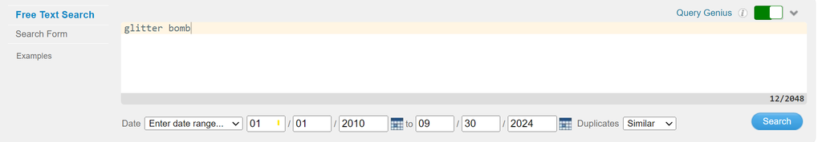

Next, I’ll scroll down to the “Region” section and select the United States.

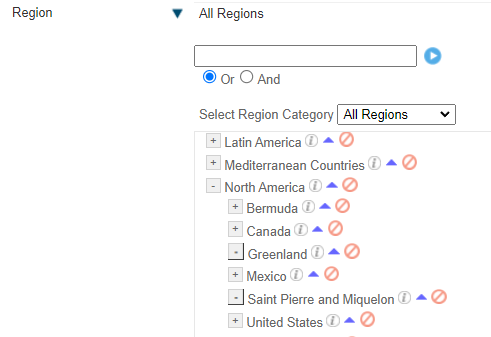

Selecting a region

You’ll notice that when you hit the little blue arrow next to the country name, `re=usa` will be added to the query terms. That’s the query language to restrict results to a particular region. However, I’ll get an error message if I try to run this as-is. I’ll need to add the word AND between my terms and the region query to indicate that I want articles containing the terms “glitter bomb” AND that come from the US.

So my search query now looks like this:

`glitter bomb AND re=usa`

Next, I’ll want to limit the subjects. Factiva contains *A LOT* of stuff other than just news, so we’ll want to filter out most of this information and just get items in the “Political/General News” category. Once again, I’ll need to add the AND operator when I add this filter.

`glitter bomb AND re=usa AND ns=gcat`

Finally, it may be redundant, but I think it can be a good idea to filter the news sources to Major News and Business Sources -> U.S. So that gives us:

`glitter bomb AND re=usa AND ns=gcat AND rst=tmnbus`

Finally, I might want to change my query language a little bit too. We’re primarily interested in the use of glitter bombs as a form of protest, but [there’s plenty of other uses](https://abc7news.com/bait-cars-glitter-bomb-backpack-mark-rober-youtube-san-francisco-car-break-in/14179723/). One simple method would be to just add terms like “protest” or “activists” to the search.

I’ll add a `*` wild card to the end of these terms so I can capture terms like “bombing” “protester” and “activists”, and I’ll add an OR statement between protests or activists to catch articles that use either term.

My final query looks like this:

`(glitter bomb*) and (protest* OR activist*) AND re=usa AND ns=gcat AND rst=tmnbus`

And returns about 41 results for the selected time period. While not all of these document a protest event (and many may document the same event more than once) its reasonably easy to filter out the wheat from the chaff. From here, I might want to start making a list of unique events, their targets and exact dates (which may not be the same as the publication date!) the number of participants and their organization affiliations etc.

Once I’m finished, it might be a good idea to export some or all of the articles for future use. I can export the text by selecting articles and then hitting the menu at the top of the search results:

[figure not shown]

If you’re trying to get a lot of stuff: Factiva Places some restrictions on the number of articles you can export at a time (I think its 100) but you can get around this by just selecting articles in batches. They do strongly discourage “data mining”, but this is somewhat of a hazy line and its unlikely you’ll run afoul of these rules with normal usage.

[Additional information about the Factiva query language](https://developer.dowjones.com/site/docs/getting_started/building_queries/legacy_search/index.gsp#)

## **Importing Factiva Articles to R**

(This information isn’t really required for this course, but it came up last semester so I’m including it here.)

If you have a lot of articles (more than a couple hundred, at a minimum) and you want to use them for something like a large scale text analysis: Kohei Watanabe has created an R package you can use to import and format data from factiva or lexisnexis for this exact purpose. If this is something you’re interested in trying out, [there’s good instructions for the import process on his github page](https://github.com/koheiw/newspapers). Keep in mind you’ll need the articles in HTML format ([here’s instructions on how to get that](https://github.com/koheiw/newspapers?tab=readme-ov-file#dow-jones-faciva))

Here’s an example of using his code to import the text of those glitter bomb related Factiva articles:

```r
# run these two lines to install the package
# once you've installed, you don't need to run them again!
install.packages("devtools")
devtools::install_github("koheiw/newspapers")
```

Import the data using the `import_factiva` function followed by the name of your files.

```r
# then load the package and use import_factiva to save your html formatted results:
library(newspapers)
glitter_stories<- import_factiva("Factiva_Glitter_Articles.html")
```

```
Reading Factiva_Glitter_Articles.html
```

```r
head(glitter_stories$head)
```

```
[1] "Animal rights activist facing felony charges after throwing glitter on interim Harvard president"
[2] "A Black Institution's Bold Visionary"
[3] "There Are Lots of Outlets for Stress Relief"
[4] "Photos: WorldPride Wraps Up with Parades and Parties"
[5] "Dems keep close eye on Omar’s missteps // Additional controversies could lead to Democratic primary challenge in 2020."
[6] "Glitter Secrets"
```

Here’s an example of creating a basic plot showing the number of articles per year. (far from the most interesting thing we could do with the data!)

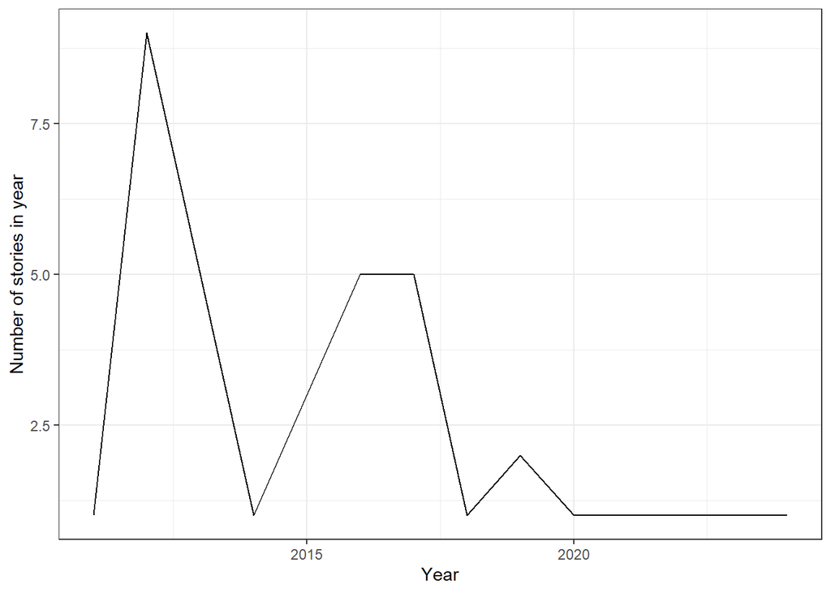

```r
library(tidyverse)

story_counts <- glitter_stories|>
  # re-format publication dates
  mutate(pubdate = dmy(date),
         pubyear = year(pubdate)
         )|>

  group_by(pubyear)|>
  summarise(n = n())|>
  arrange(pubyear)

story_plot<-ggplot(story_counts, aes(x=pubyear, y= n)) +
  geom_line() +
  theme_bw()  +
  ylab("Number of stories in year") +
  xlab("Year")

story_plot
```